# Table of Contents

**Kernel Author:**  
[Bhishan Poudel, Data Scientist, Ph.D Astrophysics](https://bhishanpdl.github.io/) .

# Description

Fraud detection using Keras.

**Resources**

- [official: Classification on imbalanced data](https://www.tensorflow.org/tutorials/structured_data/imbalanced_data)
- [official: Overfit and underfit](https://www.tensorflow.org/tutorials/keras/overfit_and_underfit)
- [official: Hyperparameter Tuning with the HParams Dashboard](https://www.tensorflow.org/tensorboard/hyperparameter_tuning_with_hparams)
- [official: keras-tuner](https://keras.io/keras_tuner/)
- [kdnuggets: Hands on Hyperparameter Tuning with Keras Tuner](https://www.kdnuggets.com/2020/02/hyperparameter-tuning-keras-tuner.html)
- [neptuneai: Keras Tuner: Lessons Learned From Tuning Hyperparameters of a Real-Life Deep Learning Model](https://neptune.ai/blog/keras-tuner-tuning-hyperparameters-deep-learning-model)
- [official: Introduction to the Keras Tuner](https://www.tensorflow.org/tutorials/keras/keras_tuner)
- [official: Hyperparameter tuning with Keras Tuner](https://blog.tensorflow.org/2020/01/hyperparameter-tuning-with-keras-tuner.html)
- [towardsdatascience: Hyperparameter Tuning with Keras Tuner](https://towardsdatascience.com/hyperparameter-tuning-with-keras-tuner-283474fbfbe)
- [analyticsvidhya: Tuning Hyperparameters of An Artificial Neural Network Leveraging Keras Tuner](https://www.analyticsvidhya.com/blog/2021/06/tuning-hyperparameters-of-an-artificial-neural-network-leveraging-keras-tuner/)

```python
import time
time_start_notebook = time.time()
```

# Colab

```python
%%capture
# capture will not print in notebook
import os
import sys
ENV_COLAB = 'google.colab' in sys.modules

if ENV_COLAB:
    # install modules
    !pip install scikit-plot
    !pip install lrcurve
    !pip install watermark
    !pip install git+https://github.com/tensorflow/docs
    !pip install keras-tuner --upgrade
    !pip install tensorflow_addons

    ## print
    print('Environment: Google Colaboratory.')
```

```python
# using GPU in colab
```

```python
import sys
ENV_COLAB = 'google.colab' in sys.modules
if ENV_COLAB:
    !nvidia-smi
```

```
NVIDIA-SMI has failed because it couldn't communicate with the NVIDIA driver. Make sure that the latest NVIDIA driver is installed and running.
```

## Imports

```python
import numpy as np
import pandas as pd
import seaborn as sns
sns.set(color_codes=True)

import matplotlib
import matplotlib.pyplot as plt
%matplotlib inline
matplotlib.rcParams['figure.figsize'] = (12, 10)
colors = plt.rcParams['axes.prop_cycle'].by_key()['color']

import os
import sys

# random state
SEED = 0
RNG = np.random.RandomState(SEED)

# Jupyter notebook settings for pandas
pd.set_option('display.max_columns', 200)
pd.set_option('display.max_rows', 100) # None for all the rows
pd.set_option('display.max_colwidth', 50)

import scipy
from scipy import stats

# scale and split
import sklearn
from sklearn.preprocessing import MinMaxScaler, StandardScaler, RobustScaler
from sklearn.model_selection import train_test_split
from sklearn.model_selection import StratifiedKFold
from sklearn import metrics

# deep learning
import tensorflow as tf
from tensorflow import keras # Do not import keras, import from tensorflow

import tensorflow_addons as tfa # tfa.metrics.F1Score
import tensorflow_docs as tfdocs
import tensorflow_docs.modeling
import tensorflow_docs.plots
from tensorboard.plugins.hparams import api as hp

# model evaluation
import scikitplot
from scikitplot import metrics as skmetrics
import lrcurve
from lrcurve import KerasLearningCurve

import keras_tuner as kt

# versions
%load_ext watermark
%watermark -a "Bhishan Poudel" -d -v -m
print()
%watermark -iv
```

```
The watermark extension is already loaded. To reload it, use:
  %reload_ext watermark
Author: Bhishan Poudel

Python implementation: CPython
Python version       : 3.7.11
IPython version      : 5.5.0

Compiler    : GCC 7.5.0
OS          : Linux
Release     : 5.4.104+
Machine     : x86_64
Processor   : x86_64
CPU cores   : 4
Architecture: 64bit


sklearn          : 0.0
tensorboard      : 2.5.0
pandas           : 1.1.5
matplotlib       : 3.2.2
numpy            : 1.19.5
sys              : 3.7.11 (default, Jul  3 2021, 18:01:19)
[GCC 7.5.0]
scipy            : 1.4.1
tensorflow       : 2.5.0
IPython          : 5.5.0
keras_tuner      : 1.0.3
tensorflow_addons: 0.13.0
lrcurve          : 2.1.0
scikitplot       : 0.3.7
seaborn          : 0.11.1
tensorflow_docs  : 0.0.0ab165fda010d80d82548b3797c1eaaf5803a00e8-
```

# Useful Scripts

```python
def show_methods(method, ncols=3):
    x = [i for i in dir(method) if i[0]!='_' ]
    return pd.DataFrame(np.array_split(x,ncols)).T.fillna('')
```

```python
def set_random_seed(seed):
    import os
    import random
    import numpy as np
    import tensorflow as tf

    os.environ['PYTHONHASHSEED']=str(seed)
    tf.random.set_seed(seed)
    np.random.seed(seed)
    random.seed(seed)
```

```python
def model_evaluation(model_name, desc, ytest, yprobs1d,df_eval=None,
                     show=True,sort_col='Recall',threshold=0.5):
    if df_eval is None:
        df_eval = pd.DataFrame({'Model': [],
                        'Description':[],
                        'Accuracy':[],
                        'Precision':[],
                        'Recall':[],
                        'F1':[],
                        'AUC':[],
                        'AUCPR':[],
                    })
    # make sure yprobs is float
    if not isinstance(yprobs1d[0],float):
        print("Make sure to use probability values.")

    # assert length
    assert len(ytest) == len(yprobs1d), "ytest and yprobs1d must of same length."

    # prediction from probs
    ypreds = (yprobs.flatten()>threshold).astype(np.int8)

    # model evaluation
    average = 'binary'
    prec,rec,thr = sklearn.metrics.precision_recall_curve(ytest,yprobs1d)
    auc_pr = sklearn.metrics.auc(rec,prec)
    row_eval = [model_name,desc,
                sklearn.metrics.accuracy_score(ytest, ypreds),
                sklearn.metrics.precision_score(ytest, ypreds, average=average),
                sklearn.metrics.recall_score(ytest, ypreds, average=average),
                sklearn.metrics.f1_score(ytest, ypreds, average=average),
                sklearn.metrics.roc_auc_score(ytest, yprobs1d),
                auc_pr
                ]

    df_eval.loc[len(df_eval)] = row_eval
    df_eval = df_eval.drop_duplicates()
    df_eval = df_eval.sort_values(sort_col)

    if show:
        display(df_eval.style.background_gradient(subset=[sort_col]))

    return df_eval
```

# Load the data

```python
ifile = "https://github.com/bhishanpdl/Datasets/blob/master/Projects/Fraud_detection/raw/creditcard.csv.zip?raw=true"
# ifile = '../data/raw/creditcard.csv.zip'

df_raw = pd.read_csv(ifile,compression='zip')
print(df_raw.shape)
df_raw.head()
```

```
(284807, 31)
```

|  | Time | V1 | V2 | V3 | V4 | V5 | V6 | V7 | V8 | V9 | V10 | V11 | V12 | V13 | V14 | V15 | V16 | V17 | V18 | V19 | V20 | V21 | V22 | V23 | V24 | V25 | V26 | V27 | V28 | … |
| --- | --- | --- | --- | --- | --- | --- | --- | --- | --- | --- | --- | --- | --- | --- | --- | --- | --- | --- | --- | --- | --- | --- | --- | --- | --- | --- | --- | --- | --- | --- |
| 0 | 0.0 | -1.359807 | -0.072781 | 2.536347 | 1.378155 | -0.338321 | 0.462388 | 0.239599 | 0.098698 | 0.363787 | 0.090794 | -0.551600 | -0.617801 | -0.991390 | -0.311169 | 1.468177 | -0.470401 | 0.207971 | 0.025791 | 0.403993 | 0.251412 | -0.018307 | 0.277838 | -0.110474 | 0.066928 | 0.128539 | -0.189115 | 0.133558 | -0.021053 | … |
| 1 | 0.0 | 1.191857 | 0.266151 | 0.166480 | 0.448154 | 0.060018 | -0.082361 | -0.078803 | 0.085102 | -0.255425 | -0.166974 | 1.612727 | 1.065235 | 0.489095 | -0.143772 | 0.635558 | 0.463917 | -0.114805 | -0.183361 | -0.145783 | -0.069083 | -0.225775 | -0.638672 | 0.101288 | -0.339846 | 0.167170 | 0.125895 | -0.008983 | 0.014724 | … |
| 2 | 1.0 | -1.358354 | -1.340163 | 1.773209 | 0.379780 | -0.503198 | 1.800499 | 0.791461 | 0.247676 | -1.514654 | 0.207643 | 0.624501 | 0.066084 | 0.717293 | -0.165946 | 2.345865 | -2.890083 | 1.109969 | -0.121359 | -2.261857 | 0.524980 | 0.247998 | 0.771679 | 0.909412 | -0.689281 | -0.327642 | -0.139097 | -0.055353 | -0.059752 | … |
| 3 | 1.0 | -0.966272 | -0.185226 | 1.792993 | -0.863291 | -0.010309 | 1.247203 | 0.237609 | 0.377436 | -1.387024 | -0.054952 | -0.226487 | 0.178228 | 0.507757 | -0.287924 | -0.631418 | -1.059647 | -0.684093 | 1.965775 | -1.232622 | -0.208038 | -0.108300 | 0.005274 | -0.190321 | -1.175575 | 0.647376 | -0.221929 | 0.062723 | 0.061458 | … |
| 4 | 2.0 | -1.158233 | 0.877737 | 1.548718 | 0.403034 | -0.407193 | 0.095921 | 0.592941 | -0.270533 | 0.817739 | 0.753074 | -0.822843 | 0.538196 | 1.345852 | -1.119670 | 0.175121 | -0.451449 | -0.237033 | -0.038195 | 0.803487 | 0.408542 | -0.009431 | 0.798278 | -0.137458 | 0.141267 | -0.206010 | 0.502292 | 0.219422 | 0.215153 | … |

# Data Processing

## Class balance

```
0    284315
1       492
Name: Class, dtype: int64
```

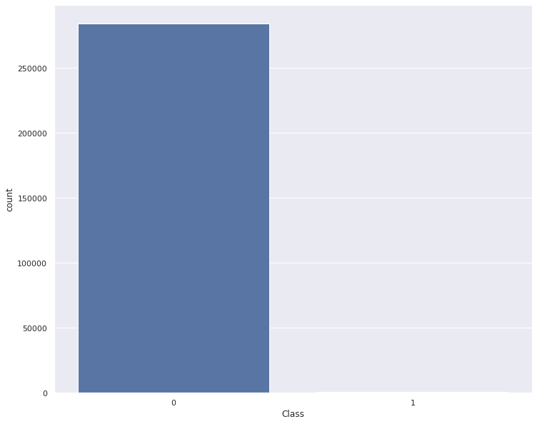

```python
target = 'Class'
display(df_raw[target].value_counts())
sns.countplot(x=df_raw[target])
```

```python
neg, pos = np.bincount(df_raw['Class'])
total = neg + pos
print('Examples:\n    Total: {}\n    Positive: {} ({:.2f}% of total)\n'.format(
    total, pos, 100 * pos / total))
```

```
Examples:
    Total: 284807
    Positive: 492 (0.17% of total)
```

## Feature Selection

```python
cols_drop = ['Time']

df = df_raw.drop(cols_drop,axis=1)
df.shape
```

```
(284807, 30)
```

## Log transform

```python
eps=0.001 # 0 => 0.1¢
df['Ammount'] = np.log(df.pop('Amount')+eps)
```

## Train-validation-test split with stratify

```python
from sklearn.model_selection import train_test_split

target = 'Class'

df_Xtrain_orig,df_Xtest,ser_ytrain_orig,ser_ytest = train_test_split(df.drop([target],axis=1),
                                             df[target],
                                             test_size=0.2,
                                             stratify=df[target],
                                             random_state=SEED)

df_Xtrain,df_Xvalid,ser_ytrain,ser_yvalid = train_test_split(df_Xtrain_orig,
                                             ser_ytrain_orig,
                                             test_size=0.2,
                                             stratify=ser_ytrain_orig,
                                             random_state=SEED)

ytrain = np.array(ser_ytrain)
yvalid = np.array(ser_yvalid)
ytest = np.array(ser_ytest)

df.shape, df_Xtrain.shape, ser_ytrain.shape
```

```
((284807, 30), (182276, 29), (182276,))
```

## Normalize the data

```python
from sklearn.preprocessing import StandardScaler

scaler = StandardScaler()
scaler.fit(df_Xtrain)

Xtrain = scaler.transform(df_Xtrain)
Xvalid = scaler.transform(df_Xvalid)
Xtest  = scaler.transform(df_Xtest)

# clip the values
Xtrain = np.clip(Xtrain, -5, 5)
Xvalid = np.clip(Xvalid, -5, 5)
Xtest = np.clip(Xtest, -5, 5)
```

# Modelling: Keras Sequential

## Bias Initializer

```python
neg, pos = np.bincount(df_raw['Class'])
total = neg + pos

bias_initializer = np.log([pos/neg])
bias_initializer
```

```
array([-6.35935934])
```

## Class weights

```python
weight_for_0 = (1 / neg)*(total)/2.0
weight_for_1 = (1 / pos)*(total)/2.0

class_weight = {0: weight_for_0, 1: weight_for_1}

print('Weight for class 0: {:.2f}'.format(weight_for_0))
print('Weight for class 1: {:.2f}'.format(weight_for_1))
```

```
Weight for class 0: 0.50
Weight for class 1: 289.44
```

# Params and Metrics

```python
n_feats = Xtrain.shape[-1]
class_weight = {0: weight_for_0, 1: weight_for_1}

#============================================================
PARAMS_MODEL = {
    # layer 1
    'L1_units': 16,
    'L1_act': 'elu',
    'L1_dropout': 0.5,

    # optimizer
    'adam_lr': 1e-3,
}

#============================================================
METRICS = [
      tf.keras.metrics.TruePositives(name='tp'),
      tf.keras.metrics.FalsePositives(name='fp'),
      tf.keras.metrics.TrueNegatives(name='tn'),
      tf.keras.metrics.FalseNegatives(name='fn'),
      tf.keras.metrics.BinaryAccuracy(name='accuracy'),
      tf.keras.metrics.Precision(name='precision'),
      tf.keras.metrics.Recall(name='recall'),
      tf.keras.metrics.AUC(name='auc'),
      tf.keras.metrics.AUC(name='prc', curve='PR'), # precision-recall curve
]

#============================================================
PARAMS_FIT = {'epochs': 100,
          'batch_size': 2048,
          'class_weight0': class_weight[0],
          'class_weight1': class_weight[1],
          'patience': 10,
          'shuffle': True,
          }

#============================================================
# callbacks
cb_early = tf.keras.callbacks.EarlyStopping(
    monitor='val_prc',
    verbose=1,
    patience=PARAMS_FIT['patience'],
    mode='max',
    restore_best_weights=True)

#cb_checkpt = keras.callbacks.ModelCheckpoint("fraud_model_at_epoch_{epoch}.h5")
cb_lr = lrcurve.KerasLearningCurve()
cb_dots = tfdocs.modeling.EpochDots()
callbacks = [cb_early, cb_lr,cb_dots]
```

# Build the Model

```python
def make_model(metrics=METRICS, bias_initializer=None,n_feats=n_feats):
    if bias_initializer is not None:
        bias_initializer = tf.keras.initializers.Constant(bias_initializer)

    model = keras.Sequential([
        # layer 1
        keras.layers.Dense(PARAMS_MODEL['L1_units'],
                           activation=PARAMS_MODEL['L1_act'],
                           kernel_regularizer=tf.keras.regularizers.l2(0.0001),
                           input_shape=(n_feats,)),

        keras.layers.Dropout(PARAMS_MODEL['L1_dropout']),

        # last layer is dense 1 with activation sigmoid
        keras.layers.Dense(1, activation='sigmoid',
                         bias_initializer=bias_initializer),
    ])

    model.compile(
      optimizer=keras.optimizers.Adam(learning_rate=PARAMS_MODEL['adam_lr']),
      loss=keras.losses.BinaryCrossentropy(),
      metrics=metrics)

    return model

model = make_model()
model.summary()
```

```
Model: "sequential_1"
_________________________________________________________________
Layer (type)                 Output Shape              Param #
=================================================================
dense_2 (Dense)              (None, 16)                480
_________________________________________________________________
dropout_1 (Dropout)          (None, 16)                0
_________________________________________________________________
dense_3 (Dense)              (None, 1)                 17
=================================================================
Total params: 497
Trainable params: 497
Non-trainable params: 0
_________________________________________________________________
```

```python
type(model)
```

```
tensorflow.python.keras.engine.sequential.Sequential
```

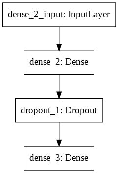

```python
from tensorflow.keras.utils import plot_model

# save keras sequential model
plot_model(model,'model_medium.png')

# For functional model
# tf.keras.utils.plot_model(model, 'model_medium.png')
```

## Fit the model

```python
%%time
set_random_seed(SEED)
model = make_model(bias_initializer=bias_initializer)

history = model.fit(
    Xtrain,
    ytrain,
    batch_size=PARAMS_FIT['batch_size'],
    epochs=PARAMS_FIT['epochs'],
    callbacks=callbacks,
    validation_data=(Xvalid, yvalid),
    verbose=0,
    class_weight=class_weight
    )
```

```
Epoch: 0, accuracy:0.9956,  auc:0.8024,  fn:191.0000,  fp:604.0000,  loss:1.5321,  prc:0.2119,  precision:0.1703,  recall:0.3937,  tn:181357.0000,  tp:124.0000,  val_accuracy:0.9989,  val_auc:0.9520,  val_fn:19.0000,  val_fp:29.0000,  val_loss:0.0130,  val_prc:0.6436,  val_precision:0.6742,  val_rec…
.............Restoring model weights from the end of the best epoch.
.Epoch 00014: early stopping
CPU times: user 23.6 s, sys: 2.49 s, total: 26.1 s
Wall time: 11.8 s
```

# Model Evaluation

## Training History Plots

```python
matplotlib.rcParams['figure.figsize'] = (12, 10)
colors = plt.rcParams['axes.prop_cycle'].by_key()['color']
```

```python
import tensorflow_docs.plots
```

```python
show_methods(tensorflow_docs.plots)
```

|  | 0 | 1 | 2 |
| --- | --- | --- | --- |
| 0 | COLOR_CYCLE | np | prop_cycle |
| 1 | HistoryPlotter | plt |  |

```python
# tfdocs.plots.HistoryPlotter?
```

```python
df_history = pd.DataFrame(history.history)
print(df_history.shape)
df_history.head(2).append(df_history.tail(2))
```

```
(14, 20)
```

|  | loss | tp | fp | tn | fn | accuracy | precision | recall | auc | prc | val_loss | val_tp | val_fp | val_tn | val_fn | val_accuracy | val_precision | val_recall | val_auc | val_prc |
| --- | --- | --- | --- | --- | --- | --- | --- | --- | --- | --- | --- | --- | --- | --- | --- | --- | --- | --- | --- | --- |
| 0 | 1.532056 | 124.0 | 604.0 | 181357.0 | 191.0 | 0.995638 | 0.170330 | 0.393651 | 0.802429 | 0.211909 | 0.012996 | 60.0 | 29.0 | 45461.0 | 19.0 | 0.998947 | 0.674157 | 0.759494 | 0.951981 | 0.643560 |
| 1 | 0.720191 | 211.0 | 1149.0 | 180812.0 | 104.0 | 0.993126 | 0.155147 | 0.669841 | 0.907501 | 0.432612 | 0.016953 | 68.0 | 49.0 | 45441.0 | 11.0 | 0.998683 | 0.581197 | 0.860759 | 0.972293 | 0.708751 |
| 12 | 0.222140 | 286.0 | 7789.0 | 174172.0 | 29.0 | 0.957109 | 0.035418 | 0.907937 | 0.971043 | 0.197877 | 0.097169 | 77.0 | 1087.0 | 44403.0 | 2.0 | 0.976102 | 0.066151 | 0.974684 | 0.985996 | 0.600866 |
| 13 | 0.245960 | 274.0 | 7859.0 | 174102.0 | 41.0 | 0.956659 | 0.033690 | 0.869841 | 0.965964 | 0.202640 | 0.099953 | 77.0 | 1124.0 | 44366.0 | 2.0 | 0.975290 | 0.064113 | 0.974684 | 0.986617 | 0.600739 |

```python
history.history.keys()
```

```
dict_keys(['loss', 'tp', 'fp', 'tn', 'fn', 'accuracy', 'precision', 'recall', 'auc', 'prc', 'val_loss', 'val_tp', 'val_fp', 'val_tn', 'val_fn', 'val_accuracy', 'val_precision', 'val_recall', 'val_auc', 'val_prc'])
```

```python
dict_history = {'medium': history}
metrics =  ['loss', 'auc', 'precision', 'recall']
```

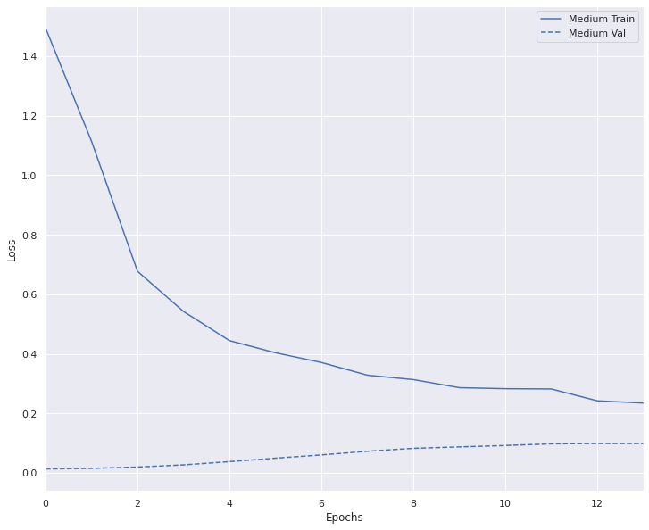

```python
# plotter can plot only one metric
plotter = tfdocs.plots.HistoryPlotter(metric = 'loss', smoothing_std=10)
plotter.plot(dict_history)
```

```python
def plot_metrics(history):
    metrics =  ['loss', 'auc', 'precision', 'recall']
    for n, metric in enumerate(metrics):
        name = metric.replace("_"," ").capitalize()
        plt.subplot(2,2,n+1)
        plt.plot(history.epoch,  history.history[metric], color=colors[0], label='Train')
        plt.plot(history.epoch, history.history['val_'+metric],
                    color=colors[0], linestyle="--", label='Val')
        plt.xlabel('Epoch')
        plt.ylabel(name)
        if metric == 'loss':
            plt.ylim([0, plt.ylim()[1]])
        elif metric == 'auc':
            plt.ylim([0.8,1])
        else:
            plt.ylim([0,1])

        plt.legend()
```

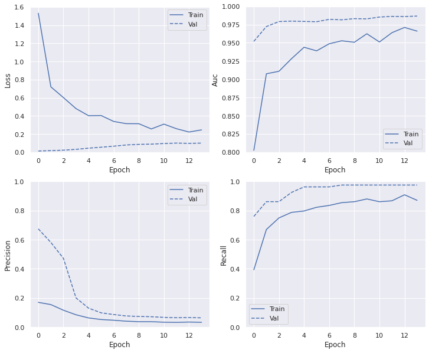

```python
plot_metrics(history)
```

**WARNING:** Here Validation data has more AUC than training, this is because dropout layer is not active when evaluating the model.

## Confusion Matrix

```python
from sklearn import metrics as skmetrics
```

```python
yprobs = model.predict(Xtest)
yprobs[:5]
```

```
array([[0.00280008],
       [0.00117731],
       [0.01025075],
       [0.00233173],
       [0.00363791]], dtype=float32)
```

```python
ypreds = (yprobs.flatten()>0.5).astype(np.int8)
ypreds[:5]
```

```
array([0, 0, 0, 0, 0], dtype=int8)
```

```python
skmetrics.confusion_matrix(ytest, ypreds)
```

```
array([[56538,   326],
       [   18,    80]])
```

```python
from scikitplot import metrics as skpmetrics
```

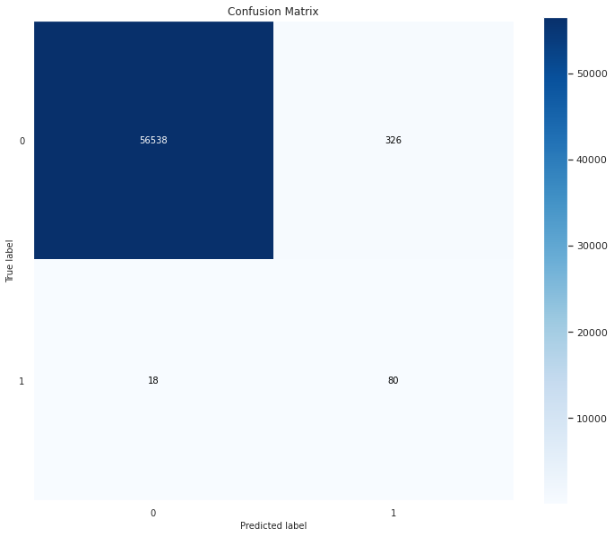

```python
skpmetrics.plot_confusion_matrix(ytest,ypreds)
```

```python
def plot_cm(labels, predictions, p=0.5):
  cm = sklearn.metrics.confusion_matrix(labels, predictions > p)
  plt.figure(figsize=(5,5))
  sns.heatmap(cm, annot=True, fmt="d")
  plt.title('Confusion matrix @{:.2f}'.format(p))
  plt.ylabel('Actual label')
  plt.xlabel('Predicted label')

  print('Legitimate Transactions Detected (True Negatives): ', cm[0][0])
  print('Legitimate Transactions Incorrectly Detected (False Positives): ', cm[0][1])
  print('Fraudulent Transactions Missed (False Negatives): ', cm[1][0])
  print('Fraudulent Transactions Detected (True Positives): ', cm[1][1])
  print('Total Fraudulent Transactions: ', np.sum(cm[1]))
```

```
Legitimate Transactions Detected (True Negatives):  56538
Legitimate Transactions Incorrectly Detected (False Positives):  326
Fraudulent Transactions Missed (False Negatives):  18
Fraudulent Transactions Detected (True Positives):  80
Total Fraudulent Transactions:  98
```

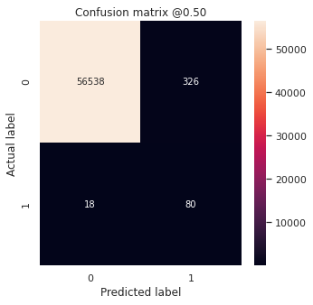

```python
plot_cm(ytest,ypreds)
```

**NOTE:** confusion matrix is TN FP FN TP Here, diagonal values are True Negatives and True Postives, ideally we want non-diagonal elements to be zero. But we some mis-predictions. The top right value is False Positive. They are not frauds but our model predict them as frauds. Company needs to send them email to verify if the transaction is legal or not and if we send too many emails it might annoy the customers. The bottom left value is False Negative. They are the actual frauds classified as normal persons by the model. This cost the company money and have to deal with fraudulent cases. This is much more undesirable than False Posivites. In real life, the trade off much be chosen much carefully so as not to bug too many customers as well as not to miss the frauds.

## Accuracy Recall Scores

```python
desc = "medium model"
yprobs = model.predict(Xtest)

ypreds = ypreds.ravel()
ypreds = (yprobs.flatten()>0.5).astype(np.int8)

df_eval = model_evaluation("keras", desc, ytest, ypreds,df_eval=None)
```

```
Make sure to use probability values.
```

|  | Model | Description | Accuracy | Precision | Recall | F1 | AUC | AUCPR |
| --- | --- | --- | --- | --- | --- | --- | --- | --- |
| 0 | keras | medium model | 0.993961 | 0.197044 | 0.816327 | 0.317460 | 0.905297 | 0.506843 |

# Hyperparameter tuning using hparams

- [Hyperparameter Tuning with the HParams Dashboard](https://www.tensorflow.org/tensorboard/hyperparameter_tuning_with_hparams)

```python
from tensorboard.plugins.hparams import api as hp
```

```python
%load_ext tensorboard
```

```
The tensorboard extension is already loaded. To reload it, use:
  %reload_ext tensorboard
```

```python
# Clear any logs from previous runs
!rm -rf ./logs/
```

```python
HP_NUM_UNITS = hp.HParam('num_units', hp.Discrete([16, 32]))
HP_DROPOUT = hp.HParam('dropout', hp.RealInterval(0.1, 0.2))
HP_OPTIMIZER = hp.HParam('optimizer', hp.Discrete(['adam', 'sgd']))

# METRIC_ACCURACY = 'accuracy'
METRIC_NAME = 'auc' # upper case AUC gives error later.
METRIC = 'AUC'

with tf.summary.create_file_writer('logs/hparam_tuning').as_default():
    hp.hparams_config(
    hparams=[HP_NUM_UNITS, HP_DROPOUT, HP_OPTIMIZER],
    metrics=[hp.Metric(METRIC, display_name=METRIC_NAME)],
  )
```

```python
cb_early = tf.keras.callbacks.EarlyStopping(
    monitor='val_'+METRIC_NAME,
    verbose=1,
    patience=PARAMS_FIT['patience'],
    mode='max',
    restore_best_weights=True)

cb_dots = tfdocs.modeling.EpochDots()
callbacks = [cb_early, cb_dots]
```

```python
def train_test_model(hparams):
    model = tf.keras.models.Sequential([

    # first layer
    tf.keras.layers.Dense(hparams[HP_NUM_UNITS],
                          activation=tf.nn.relu,
                          input_shape=(n_feats,)),
    tf.keras.layers.Dropout(hparams[HP_DROPOUT]),

    # last layer
    tf.keras.layers.Dense(1, activation='sigmoid'),
    ])
    model.compile(
      optimizer=hparams[HP_OPTIMIZER],
      loss='binary_crossentropy',
      metrics=[METRIC],
    )

    model.fit(Xtrain,
            ytrain,
            batch_size=PARAMS_FIT['batch_size'],
            epochs=PARAMS_FIT['epochs'],
            callbacks=callbacks,
            validation_data=(Xvalid, yvalid),
            class_weight=class_weight,
            verbose=0,
            )
    _, mymetric = model.evaluate(Xvalid, yvalid)
    return mymetric
```

```python
show_methods(tf.summary)
```

|  | 0 | 1 | 2 |
| --- | --- | --- | --- |
| 0 | SummaryWriter | graph | text |
| 1 | audio | histogram | trace_export |
| 2 | create_file_writer | image | trace_off |
| 3 | create_noop_writer | record_if | trace_on |
| 4 | experimental | scalar | write |
| 5 | flush | should_record_summaries |  |

```python
hparams = {
    HP_NUM_UNITS: HP_NUM_UNITS.domain.values[0],
    HP_DROPOUT: HP_DROPOUT.domain.min_value,
    HP_OPTIMIZER: HP_OPTIMIZER.domain.values[0],
}

hp.hparams(hparams)  # record the values used in this trial
mymetric = train_test_model(hparams)
tf.summary.scalar(METRIC, mymetric, step=1)
```

```
Epoch: 0, auc:0.7376,  loss:0.6258,  val_auc:0.9782,  val_loss:0.5502,
............Restoring model weights from the end of the best epoch.
.Epoch 00013: early stopping
```

```
<tf.Tensor: shape=(), dtype=bool, numpy=False>
```

```python
def run(run_dir, hparams):
    mymetric = None
    with tf.summary.create_file_writer(run_dir).as_default():
        hp.hparams(hparams)  # record the values used in this trial
        mymetric = train_test_model(hparams)
        tf.summary.scalar(METRIC, mymetric, step=1)
    return mymetric
```

```python
session_num = 0
lst_series = []

for num_units in HP_NUM_UNITS.domain.values:
    for dropout_rate in (HP_DROPOUT.domain.min_value, HP_DROPOUT.domain.max_value):
        for optimizer in HP_OPTIMIZER.domain.values:
            hparams = {
              HP_NUM_UNITS: num_units,
              HP_DROPOUT: dropout_rate,
              HP_OPTIMIZER: optimizer,
            }
            run_name = "run-%d" % session_num
            print('\n--- Starting trial: %s' % run_name)
            dict_params = {h.name: hparams[h] for h in hparams}
            ser = pd.Series(dict_params)

            mymetric = run('logs/hparam_tuning/' + run_name, hparams)
            ser[METRIC_NAME] = mymetric
            lst_series.append(ser)
            session_num += 1

# epoch 0 auc: are values before fitting
# loss: auc: are values after fitting.
```

```
--- Starting trial: run-0

Epoch: 0, auc:0.8588,  loss:0.4884,  val_auc:0.9912,  val_loss:0.5324,
............Restoring model weights from the end of the best epoch.
.Epoch 00013: early stopping

--- Starting trial: run-1

Epoch: 0, auc:0.8652,  loss:0.5198,  val_auc:0.9674,  val_loss:0.6584,
...................................................Restoring model weights from the end of the best epoch.
.Epoch 00052: early stopping

--- Starting trial: run-2

Epoch: 0, auc:0.6288,  loss:0.7768,  val_auc:0.9292,  val_loss:0.5340,
....................Restoring model weights from the end of the best epoch.
.Epoch 00021: early stopping

--- Starting trial: run-3

Epoch: 0, auc:0.8563,  loss:0.5908,  val_auc:0.9561,  val_loss:0.7649,
....................................................Restoring model weights from the end of the best epoch.
.Epoch 00053: early stopping

--- Starting trial: run-4

Epoch: 0, auc:0.7864,  loss:0.5691,  val_auc:0.9792,  val_loss:0.4454,
.................Restoring model weights from the end of the best epoch.
.Epoch 00018: early stopping

--- Starting trial: run-5

Epoch: 0, auc:0.9033,  loss:0.4280,  val_auc:0.9810,  val_loss:0.5153,
.................................Restoring model weights from the end of the best epoch.
.Epoch 00034: early stopping

--- Starting trial: run-6

Epoch: 0, auc:0.8931,  loss:0.4900,  val_auc:0.9886,  val_loss:0.5400,
...............Restoring model weights from the end of the best epoch.
.Epoch 00016: early stopping

--- Starting trial: run-7

Epoch: 0, auc:0.8325,  loss:0.5484,  val_auc:0.9778,  val_loss:0.6555,
................Restoring model weights from the end of the best epoch.
.Epoch 00017: early stopping
```

```python
df_hpo = pd.concat(lst_series,axis=1).T # hyperparameter optimization dataframe

df_hpo['num_units'] = df_hpo['num_units'].astype(int)
df_hpo[['dropout','auc']] = df_hpo[['dropout','auc']].astype(float)
df_hpo.sort_values('auc').style.background_gradient(subset=['auc'])
```

|  | num_units | dropout | optimizer | auc |
| --- | --- | --- | --- | --- |
| 3 | 16 | 0.200000 | sgd | 0.986942 |
| 1 | 16 | 0.100000 | sgd | 0.987914 |
| 5 | 32 | 0.100000 | sgd | 0.990269 |
| 7 | 32 | 0.200000 | sgd | 0.992330 |
| 4 | 32 | 0.100000 | adam | 0.993755 |
| 6 | 32 | 0.200000 | adam | 0.995096 |
| 2 | 16 | 0.200000 | adam | 0.995921 |
| 0 | 16 | 0.100000 | adam | 0.997168 |

```python
%tensorboard --logdir logs/hparam_tuning
```

```
Reusing TensorBoard on port 6006 (pid 2678), started 1:18:47 ago. (Use '!kill 2678' to kill it.)
```

```python
# predict using best model from hyperparameter tuning
```

```python
params_best = df_hpo.nlargest(1,'auc').iloc[0].to_dict()
params_best = {i:v for i,v in params_best.items() if i !='auc'}

params_best
```

```
{'dropout': 0.1, 'num_units': 16, 'optimizer': 'adam'}
```

```python
model = tf.keras.models.Sequential([

    # first layer
    tf.keras.layers.Dense(params_best['num_units'],
                          activation=tf.nn.relu,
                          input_shape=(n_feats,)),
    tf.keras.layers.Dropout(params_best['dropout']),

    # last layer
    tf.keras.layers.Dense(1, activation='sigmoid'),
  ])

# compile the model
model.compile(
      optimizer=params_best['optimizer'],
      loss='binary_crossentropy',
      metrics=[METRIC],
  )

# fit the model
history = model.fit(Xtrain,
            ytrain,
            batch_size=PARAMS_FIT['batch_size'],
            epochs=PARAMS_FIT['epochs'],
            callbacks=callbacks,
            validation_data=(Xvalid, yvalid),
            class_weight=class_weight,
            verbose=0,
            )

# prediction
yprobs = model.predict(Xtest)
ypreds = (yprobs.flatten()>0.5).astype(np.int8)

df_eval = model_evaluation("keras hparams", desc, ytest, ypreds,df_eval=df_eval)
```

```
Epoch: 0, auc:0.8512,  loss:0.4795,  val_auc:0.9589,  val_loss:0.4121,
..................Restoring model weights from the end of the best epoch.
.Epoch 00019: early stopping
Make sure to use probability values.
```

|  | Model | Description | Accuracy | Precision | Recall | F1 | AUC | AUCPR |
| --- | --- | --- | --- | --- | --- | --- | --- | --- |
| 0 | keras | medium model | 0.993961 | 0.197044 | 0.816327 | 0.317460 | 0.905297 | 0.506843 |
| 1 | keras hparams | medium model | 0.978494 | 0.066872 | 0.887755 | 0.124375 | 0.933203 | 0.477410 |

```python
df_eval
```

|  | Model | Description | Accuracy | Precision | Recall | F1 | AUC | AUCPR |
| --- | --- | --- | --- | --- | --- | --- | --- | --- |
| 0 | keras | medium model | 0.993961 | 0.197044 | 0.816327 | 0.317460 | 0.905297 | 0.506843 |
| 1 | keras hparams | medium model | 0.978494 | 0.066872 | 0.887755 | 0.124375 | 0.933203 | 0.477410 |

# Hyperparameter tuning using keras-tuner

- [official: Introduction to the Keras Tuner](https://www.tensorflow.org/tutorials/keras/keras_tuner)
- [official: Hyperparameter tuning with Keras Tuner](https://blog.tensorflow.org/2020/01/hyperparameter-tuning-with-keras-tuner.html)
- [towardsdatascience: Hyperparameter Tuning with Keras Tuner](https://towardsdatascience.com/hyperparameter-tuning-with-keras-tuner-283474fbfbe)
- [analyticsvidhya: Tuning Hyperparameters of An Artificial Neural Network Leveraging Keras Tuner](https://www.analyticsvidhya.com/blog/2021/06/tuning-hyperparameters-of-an-artificial-neural-network-leveraging-keras-tuner/)

```python
import keras_tuner as kt

show_methods(kt)
```

|  | 0 | 1 | 2 |
| --- | --- | --- | --- |
| 0 | BayesianOptimization | Oracle | distribute |
| 1 | CloudLogger | RandomSearch | division |
| 2 | HyperModel | SklearnTuner | engine |
| 3 | HyperParameter | Tuner | oracles |
| 4 | HyperParameters | absolute_import | print_function |
| 5 | Hyperband | applications | protos |
| 6 | Logger | check_tf_version | tuners |
| 7 | Objective | config | utils |

## Build hypermodel

```python
from keras_tuner import HyperModel, RandomSearch, Hyperband, BayesianOptimization
```

```python
METRICS = [
      keras.metrics.TruePositives(name='tp'),
      keras.metrics.FalsePositives(name='fp'),
      keras.metrics.TrueNegatives(name='tn'),
      keras.metrics.FalseNegatives(name='fn'),
      keras.metrics.BinaryAccuracy(name='accuracy'),
      keras.metrics.Precision(name='precision'),
      keras.metrics.Recall(name='recall'),
      keras.metrics.AUC(name='auc'),
      keras.metrics.AUC(name='prc', curve='PR'), # precision-recall curve
]
```

```python
class BinaryClassificationHyperModel(HyperModel):
    def __init__(self, input_shape,bias_initializer):
        self.input_shape = input_shape
        self.bias_initializer = tf.keras.initializers.Constant(bias_initializer)

    def build(self, hp):
        # parameters
        hp_units1 = hp.Int('units1',16,48,16,default=16)
        hp_act1 = hp.Choice(
            'dense_activation',
            values=['relu','elu'],
            default='relu',
            )
        hp_dropout1 = hp.Float(
            'dropout',
            min_value=0.2,
            max_value=0.7,
            default=0.5,
            step=0.1)

        hp_learning_rate = hp.Choice('learning_rate', values=[1e-2, 1e-3, 1e-4])
        hp_optimizers = hp.Choice('optimizer',values=['adam','sgd'])

        # define the model
        model = tf.keras.Sequential()

        # first layer
        model.add(
            tf.keras.layers.Dense(
                units=hp_units1,
                activation=hp_act1,
                kernel_initializer='zeros',
                bias_initializer='zeros',
                input_shape=input_shape
            )
        )
        model.add(tf.keras.layers.Dropout(hp_dropout1))


        # last layer
        model.add(tf.keras.layers.Dense(1, activation='sigmoid',
                               bias_initializer=self.bias_initializer)
        )

        model.compile(
            optimizer='adam',loss='binary_crossentropy',metrics=METRICS
        )

        return model

input_shape = (Xtrain.shape[1],)
bias_initializer = bias_initializer # np array of one element
hypermodel = BinaryClassificationHyperModel(input_shape,bias_initializer)
```

## Keras tuner Random Search

```python
# kt.RandomSearch?
```

```python
tuner_rs = kt.RandomSearch(
            hypermodel,
            objective=kt.Objective("val_prc", direction="max"),
            seed=SEED,
            max_trials=4,
            executions_per_trial=1,
            overwrite=True
        )
```

```python
show_methods(tuner_rs)
```

|  | 0 | 1 | 2 |
| --- | --- | --- | --- |
| 0 | directory | on_batch_end | remaining_trials |
| 1 | distribution_strategy | on_epoch_begin | results_summary |
| 2 | executions_per_trial | on_epoch_end | run_trial |
| 3 | get_best_hyperparameters | on_search_begin | save |
| 4 | get_best_models | on_search_end | save_model |
| 5 | get_state | on_trial_begin | search |
| 6 | get_trial_dir | on_trial_end | search_space_summary |
| 7 | hypermodel | oracle | seed |
| 8 | load_model | project_dir | set_state |
| 9 | logger | project_name | tuner_id |
| 10 | on_batch_begin | reload |  |

```python
# tuner_rs.search?
# tuner_rs.search(*fit_args, **fit_kwargs)
```

```python
%%time
tuner_rs.search(Xtrain, ytrain,
                epochs=2,
                validation_split=0.2,
                verbose=1,
                )
```

```
Trial 4 Complete [00h 00m 24s]
val_prc: 0.7927567958831787

Best val_prc So Far: 0.8070851564407349
Total elapsed time: 00h 02m 13s
INFO:tensorflow:Oracle triggered exit
CPU times: user 2min 8s, sys: 15.9 s, total: 2min 24s
Wall time: 2min 13s
```

```python
best_model = tuner_rs.get_best_models(num_models=1)[0]

# prediction
yprobs = best_model.predict(Xtest)
ypreds = (yprobs.flatten()>0.5).astype(np.int8)

df_eval = model_evaluation("keras-tuner randomsearch", desc, ytest, ypreds,df_eval=df_eval)
```

```
Make sure to use probability values.
```

|  | Model | Description | Accuracy | Precision | Recall | F1 | AUC | AUCPR |
| --- | --- | --- | --- | --- | --- | --- | --- | --- |
| 2 | keras-tuner randomsearch | medium model | 0.999298 | 0.853659 | 0.714286 | 0.777778 | 0.857037 | 0.784218 |
| 0 | keras | medium model | 0.993961 | 0.197044 | 0.816327 | 0.317460 | 0.905297 | 0.506843 |
| 1 | keras hparams | medium model | 0.978494 | 0.066872 | 0.887755 | 0.124375 | 0.933203 | 0.477410 |

## keras tuner hyperband

- [official: Introduction to the Keras Tuner](https://www.tensorflow.org/tutorials/keras/keras_tuner#setup)

Hyperband determines the number of models to train in a bracket by computing `1 + log_factor(max_epochs)` and rounding it up to the nearest integer.

```python
tuner_hb = kt.Hyperband(
            hypermodel,
            max_epochs=2,
            objective=kt.Objective("val_auc", direction="max"),
            seed=SEED,
            executions_per_trial=1,
            hyperband_iterations=2,
            # factor=3,
            # directory='my_dir',
            # project_name='hyperband'
            overwrite=True,
        )

cb_early = tf.keras.callbacks.EarlyStopping(
    monitor='val_prc',
    verbose=1,
    patience=5,
    mode='max',
    restore_best_weights=True)

tuner_hb.search(Xtrain, ytrain,
                epochs=10,
                validation_split=0.2,
                verbose=1,
                callbacks = [cb_early] # patience must be smaller than max_epochs
                )

best_model = tuner_hb.get_best_models(num_models=1)[0]
```

```
Trial 4 Complete [00h 00m 24s]
val_auc: 0.9214053153991699

Best val_auc So Far: 0.9292096495628357
Total elapsed time: 00h 01m 33s
INFO:tensorflow:Oracle triggered exit
```

```python
best_model = tuner_hb.get_best_models(num_models=1)[0]

# prediction
yprobs = best_model.predict(Xtest)
ypreds = (yprobs.flatten()>0.5).astype(np.int8)

df_eval = model_evaluation("keras-tuner hyperband", desc, ytest, ypreds,df_eval=df_eval)
```

[output not shown]

|  | Model | Description | Accuracy | Precision | Recall | F1 | AUC | AUCPR |
| --- | --- | --- | --- | --- | --- | --- | --- | --- |
| 3 | keras-tuner hyperband | medium model | 0.999228 | 0.846154 | 0.673469 | 0.750000 | 0.836629 | 0.760093 |
| 2 | keras-tuner randomsearch | medium model | 0.999298 | 0.853659 | 0.714286 | 0.777778 | 0.857037 | 0.784218 |
| 0 | keras | medium model | 0.993961 | 0.197044 | 0.816327 | 0.317460 | 0.905297 | 0.506843 |
| 1 | keras hparams | medium model | 0.978494 | 0.066872 | 0.887755 | 0.124375 | 0.933203 | 0.477410 |

## Use the best model iteration

- [offiical: Introduction to the Keras Tuner](https://www.tensorflow.org/tutorials/keras/keras_tuner#setup)

```python
# Get the optimal hyperparameters
best_hps=tuner_hb.get_best_hyperparameters(num_trials=1)[0]

# Build the model with the optimal hyperparameters and train it on the data for N epochs
model = tuner_hb.hypermodel.build(best_hps)

history = model.fit(Xtrain, ytrain, epochs=10, validation_split=0.2)

val_auc_per_epoch = history.history['val_prc']

best_epoch = val_auc_per_epoch.index(max(val_auc_per_epoch)) + 1
print('Best epoch: %d' % (best_epoch,))
```

```
Best epoch: 9
```

```python
# Re-instantiate the hypermodel and train it with the optimal number of epochs from above.
hypermodel = tuner_hb.hypermodel.build(best_hps)

# Retrain the model
hypermodel.fit(Xtrain, ytrain, epochs=best_epoch, validation_split=0.2)
```

```
<tensorflow.python.keras.callbacks.History at 0x7f07ab031f50>
```

```python
# Model evaluation
eval_result = hypermodel.evaluate(Xtest, ytest)
print(eval_result)
```

```
[0.003385783638805151, 73.0, 13.0, 56851.0, 25.0, 0.9993329048156738, 0.8488371968269348, 0.7448979616165161, 0.9326589107513428, 0.7960590720176697]
```

# Time Taken

```python
time_taken = time.time() - time_start_notebook
h,m = divmod(time_taken,60*60)
print('Time taken to run whole notebook: {:.0f} hr '\
      '{:.0f} min {:.0f} secs'.format(h, *divmod(m,60)))
```

```
Time taken to run whole notebook: 0 hr 13 min 9 secs
```